# Suite de l’analyse descriptive du jeu de données SIWIM

# 1. Introduction

Nous poursuivons dans cette section notre analyse descriptive du jeu de données par l’utilisation des techniques d’analyses multidimensionnelles.

Nous appliquons dans cette section des algorithmes d’ **analyses factorielles** et de **clustering non supervisé**.

Nous choisissons de poursuivre nos analyses sur la base du jeu de données dont les données manquantes ont été imputées.

# 2. Analyse Factorielles

Les analyses factorielles permettent de résumer l’information contenues dans nos données.

Nous souhaitons avoir les réponses aux questions suivantes :

- Quels sont les camions qui se ressemblent (proximité entre les individus) ?
- Sur quelles caractéristiques sont fondées les ressemblances / dissemblances ?
- Quelles sont les relations entre les variables ?
- Quelles sont les relations entres les modalités et les variables quantitatives ?

## 2.1 Analyse Factorielle des Donnees Mixtes (AFDM)

Etudions la variance (inertie) expliquée par les axes de l’analyse factorielle :

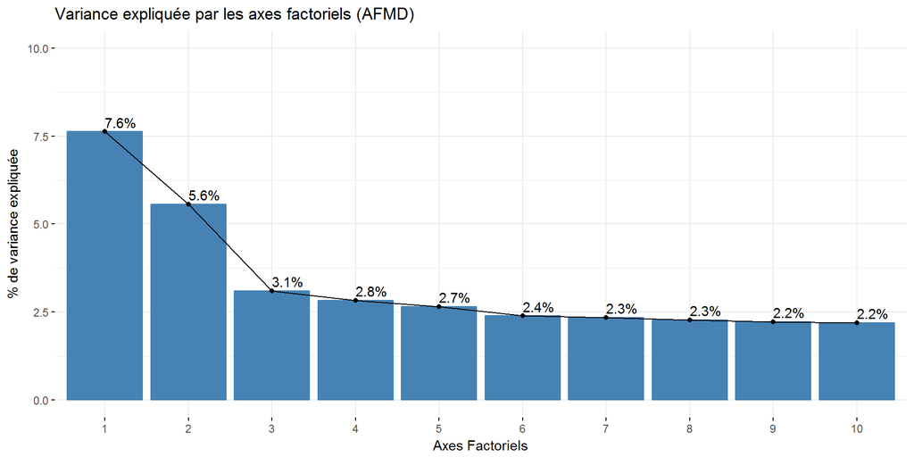

**13 %** de l’inertie totale expliquée par le **premier plan factoriel**.

**Cela est relativement faible**.

Constat :

- insuffisant pour une réduction de dimension à utiliser en entrée d’un traitement ultérieur. Garder un grand nombre d’axes nous ferait travailler avec trop de données.
- Le but recherché est de trouver une représentation synthétique des donnée, afin de notamment caractériser des groupes de camions par clustering s’appuyant sur cette représentation.

Les variables qualitatives sont essentiellement des variables de contexte (heure, jour, mois de passage, ainsi que la variable `Anomalie` déclenchée par le système de pesage.) Les variables quantitatives sont essentiellement des descripteurs des camions.

Nous proposons donc d’appliquer une Analyse en Composantes Principales sur les données quantitatives avec les **variables qualitatives en illustration**. Ces variables qualitatives ne participeront pas à la construction des axes, mais en faciliteront leur description.

## 2.2 Analyse en Composantes Principales (ACP)

### 2.2.1 Variance / Inertie Expliquee

Etudions la variance (inertie) expliquée par les axes de l’analyse factorielle :

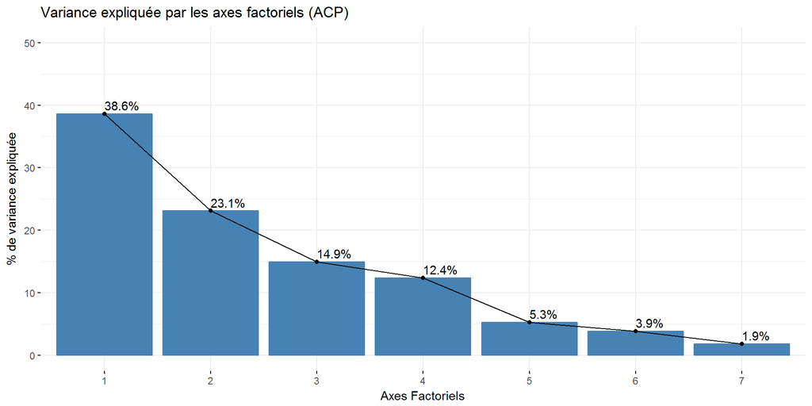

- 100 % de l’information est contenue dans les 7 variables quantitatives
- 89% de l’information résumée par les 4 premières composantes principales
- 61 % par le premier plan factoriel

Pour la suite, **nous conserverons les 4 premiers axes capturant 89 % de la variabilité :**

- Nous travaillerons ainsi avec moins de données
- La variabilité des trois axes non retenus est assimilée à du bruit

Le premier plan factoriel, présente l’intérêt d’être facilement interprétable (dimension 2) et de résumer 61 % de l’information. Les représentations graphiques qui suivront concerneront ce plan.

### 2.2.2 Graphiques des individus

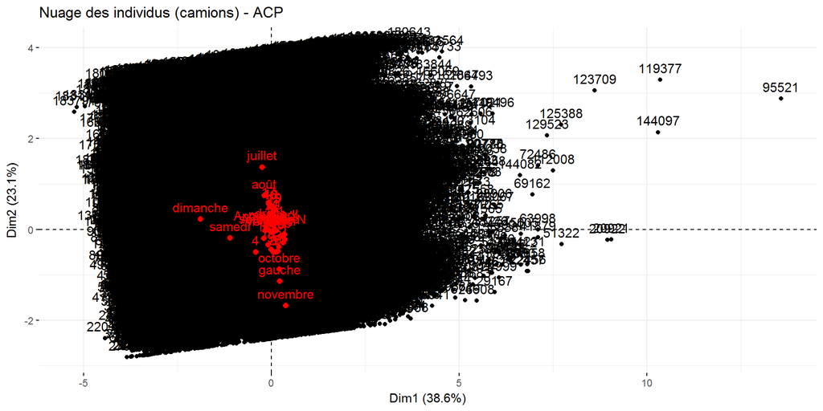

- Trop d’individus affichés, groupes invisibles à l’oeil nu
- Detection d’individu se détachant par leur valeur (exemple : **95521**) : s’agit-il d’un outlier ou d’un parangon (représentant de sa classe) ?
- le nuage des modalités des variables qualitatives se “concentre” au centre du plan => pas de corrélation notable entre ces modalités et les variables qui décrivent les axes factoriels

Nous allons analyser visuellement la qualité de représentation des individus (cos2) :

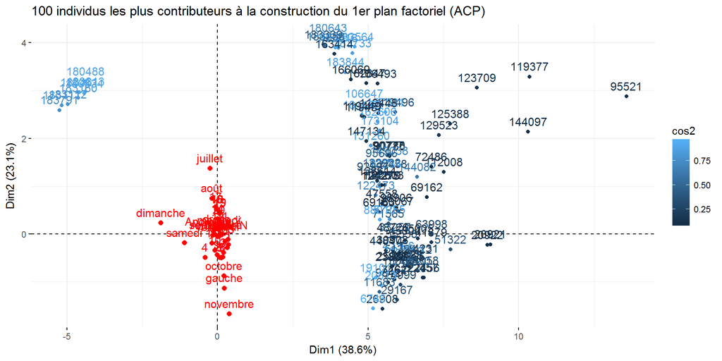

Représentation des 100 individus ayant le plus contribué à la construction des deux axes du plan factoriel principal, en colorant suivant la qualité de la représentation du poin.

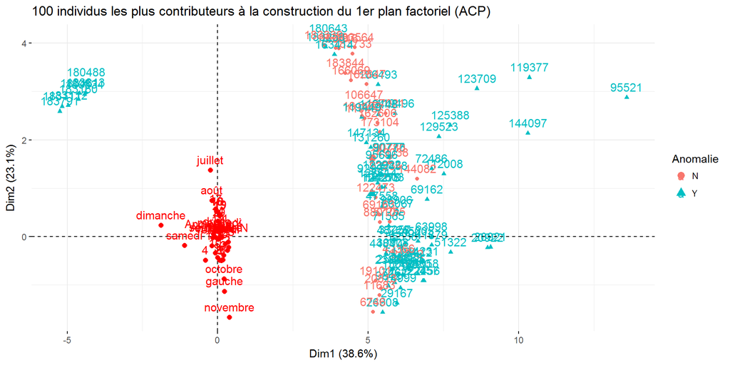

La majorité des 100 contributeurs les plus fort à la construction des axes a déclenchée une anomalie (1 camion sur trois sur le jeu de donnée entier)

Ceci parait potentiellement cohérent avec les éventuelles valeurs fortes que prendraient ces camions par rapport à certaines valeurs physiques (surpoids).

### 2.2.3 Graphique des variables

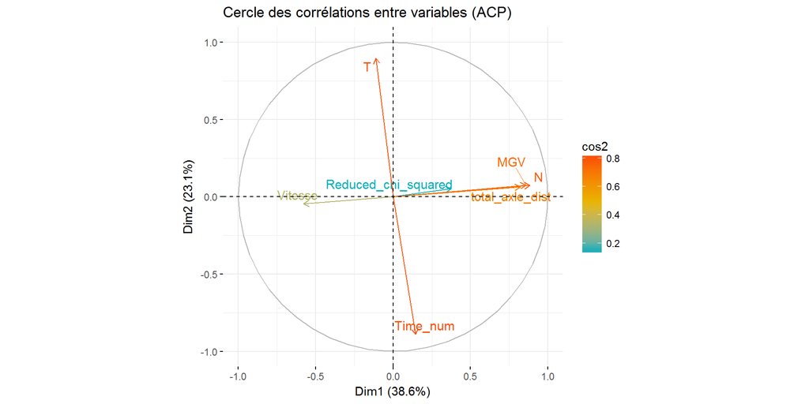

Ce graphique montre les relations entre les variables qui sont regroupées quand elles sont corrélées.

**Le premier axe oppose les camions les plus volumineux (car nombre d’essieux importants, masse importante, et longueur importante) au camion les plus petits, les moins lourds et qui sont les plus rapides.**

**Le deuxième axe montre que la température `T` est corrélée négativement à la variable `Time_Num` qui est la variable de temps (continue).**

la qualité de représentation (le cos2) est très bonne pour `N`et `total_axle_dist` et `MGV`. `Vitesse` n’a pas une représentation excellente Sur l’axe 2, `T` et `Time_Num` sont très bien représentées.

### 2.2.4 Contributions des variables aux axes principaux

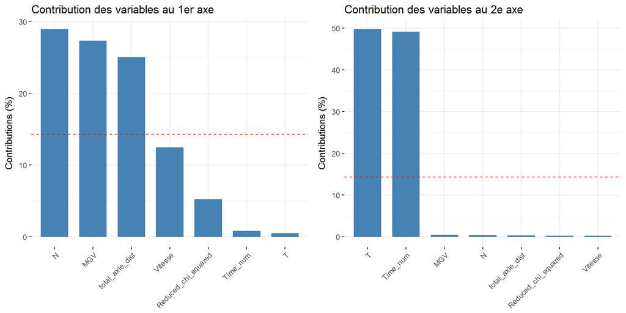

# 3. Clustering (apprentissage non supervisé)

Nous avons vu précédemment que suite à l’ACP, les 4 premières composantes principales expliquaient 89 % de la variabilité. Nous réduisons donc notre nuage de point en effectuant une nouvelle ACP en ne conservant que les 4 premières variables.

Chaque algorithme de clustering sera exécuté sur ce nouvel ensemble. **Le but est de construire une typologie des camions circulant sur le pont**.

## 3.1 kmeans + CAH sur composantes principales (méthode hierarchique)

Les méthodes hiérarchiques présentent l’intérêt de proposer un nombre optimal de cluster, dont le découpage est réalisé en optimisant un critère.

Problème : Notre jeu de données contient environ 190 000 individus, **ce qui nous expose à des problèmes calculatoires et de mémoire.**

Solution envisagée : Utilisation d’une méthode mixte en deux étapes :

- partitionnant du jeu de données avec Kmeans sur un grand nombre de classes
- réalisation d’une Classification Ascendante Hiérarchique sur le centre des classes

On effectue ensuite une CAH sur les centres des classes :

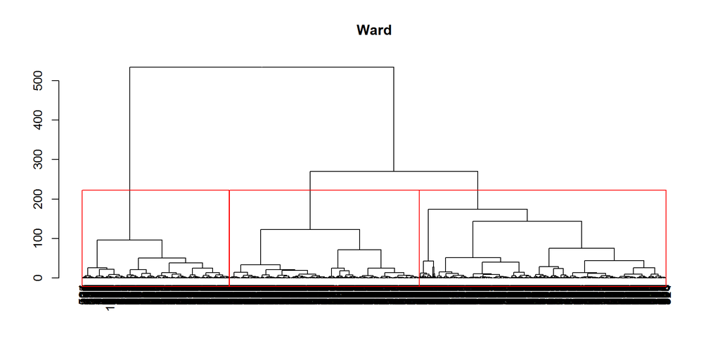

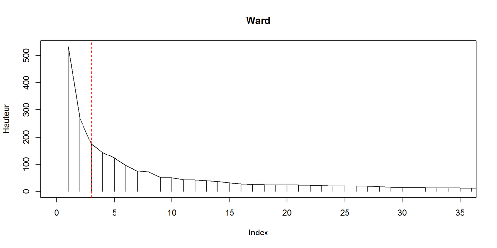

Un niveau de coupure à 3 ou 4 classes semble être envisageable. Nous décidons de couper à 3 classes.

Représentons sur le premier axe factoriels, les individus colorés en fonction de leur groupe déterminés par la CAH mixte.

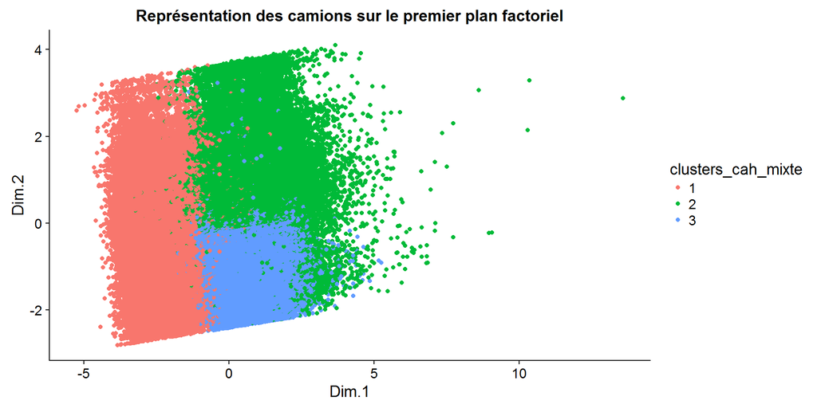

## 3.2 Partitionnement : K-means sur composantes principales

Ici, seule la méthode kmeans est utilisée. Le nombre de classes fixé à 3, est celui trouvé précédemment avec la CAH.

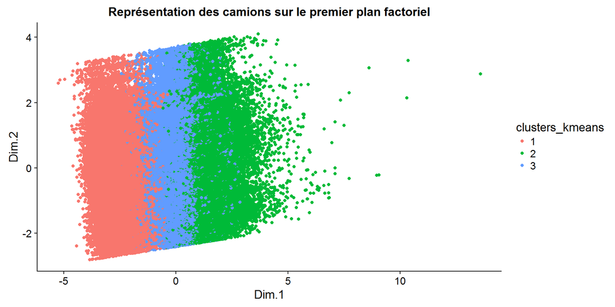

## 3.3 Partitionnement k - medoides : CLARA sur composantes principales

CLARA est l’acronyme de Clustering Large Application.

Un medoïde est le représentant le plus central d’une classe. L’algorithme des k-medoïdes réalise un partitionnement plus robuste vis à vis des données aberrantes, que celui des k-means.

Il s’agit d’un extension aux méthodes k-medoides pour **traiter de grands jeux de données** (plusieurs milliers d’observations). Elle est donc adaptée à notre contexte :

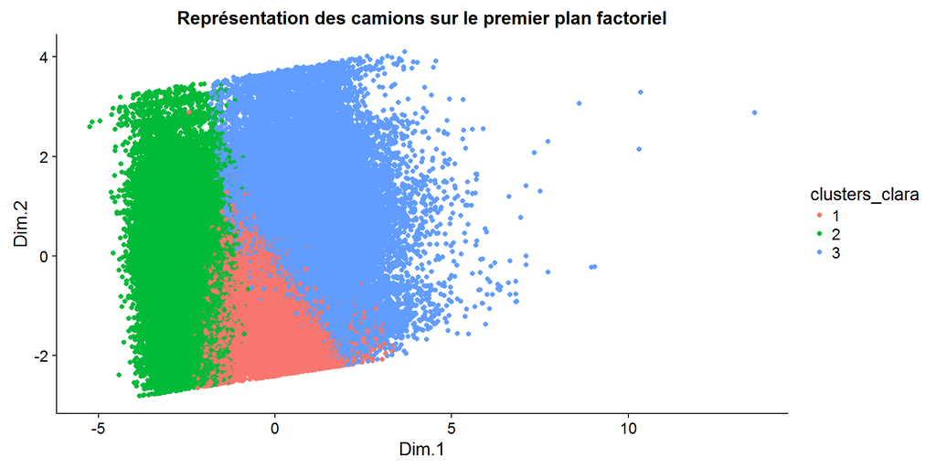

## 3.4 Partitionnement basé sur densité : DBSCAN sur composantes principales

DBSCAN est un algorithme de partitionnement de type “densité”. Il s’appuie sur la densité des données pour réaliser le partitionnement.

L’algorithme utilise deux parametres : la distance epsilon et le nombre de points minimum devant se trouver dans un rayon epsilon pour considerer ces points comme un cluster.

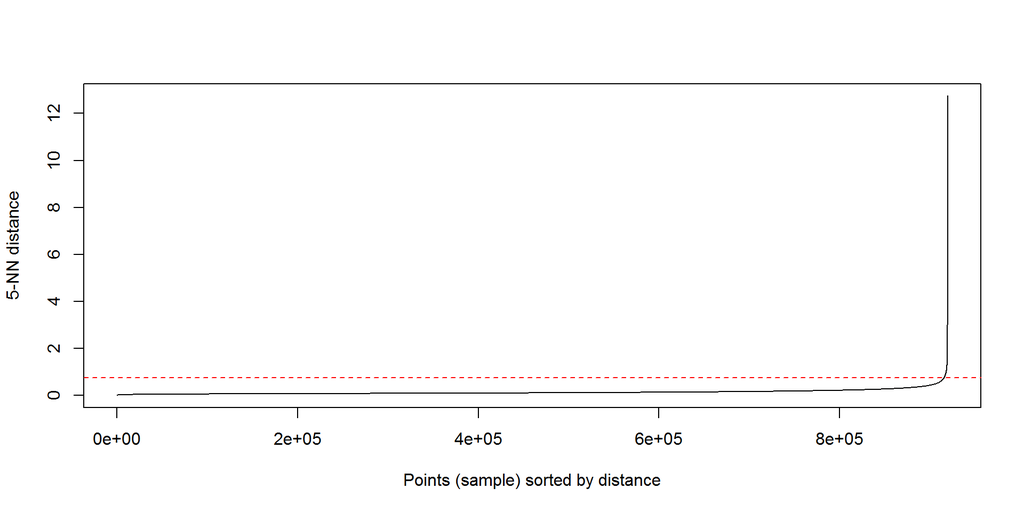

Nous executons ensuite DBSCAN avec les paramètres eps et minPts de l’heuristique précédente.

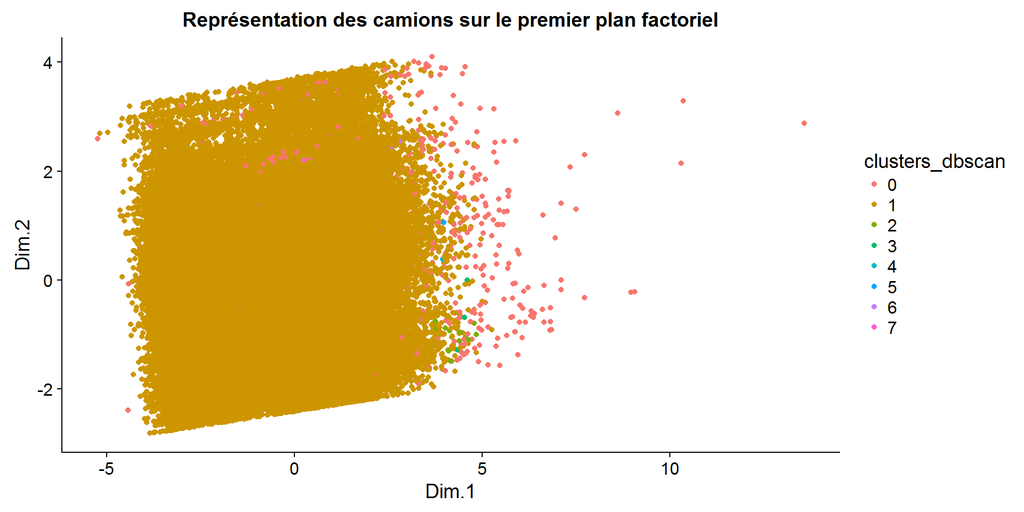

L’algorithme propose ici **7 clusters**.

## 3.5 Autres méthodes (non testées)

Nous listons ici des méthodes non testées, mais revetant un intéret dans la poursuite de l’exploration de nos données.

### 3.5.1 Partitionnement k - medoides : PAM

PAM (Partitioning Around Medoid) est une implémentation populaire mais nécessite de calculer les distances entre chaque individus pris deux à deux et pénalise ainsi la scalabilité que nous rencontrons dans notre cas.

### 3.5.2 Partitionnement basé sur densité : OPTICS

Cet algorithme est similaire à DBSCAN et élimine son principal défaut : l’impossibilité de détecter des partitions de densités différentes.

### 3.5.3 Méthodes neuronales : cartes auto-adaptatives de Kohonen (SOM)

Les cartes de Kohonen forment une classe de neurones artificiels, formant une méthode d’apprentissage non supervisé. L’algorithme est très léger en temps de calcul, permet de détecter des relations non linéaires mais présente l’inconvénient que les relations entre neurones ne peuvent être cassées pour une meilleure représentation des données. L’algorithme “Growing Neural Gas” corrige ce problème.

## 3.6 Synthèse et interprétation des classes

Nous interprétons les classes construites dans chaque méthode. L’idée est de dégager une interprétation commune, favorisant l’utilité métier.

L’interprétation des classes est réalisée en comparant la moyenne de chaque variable quantitatives de chaque classe, à la moyenne de la population globale de cette même variable.

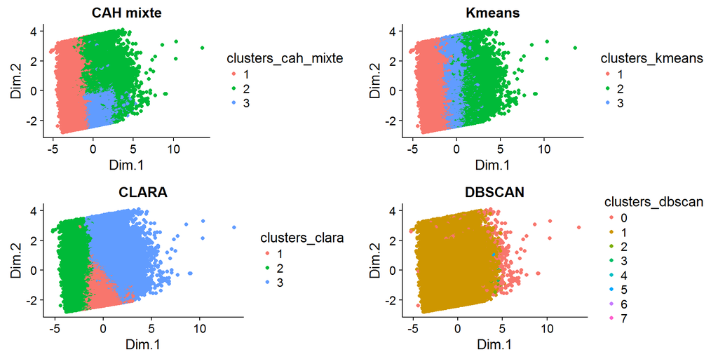

Nous choisissons de conserver la partition en **trois groupes réalisée via Kmeans** sur les 4 premiers axes de l’analyse en composantes principales. Le critère de choix est essentiellement lié à l’interprétation des classes.

**Le groupe 1** comprend des camions ayant une longueur, un nombre d’essieux, une masse nettement inférieure à la moyenne, dont la vitesse est en moyenne supérieure. **Ce groupe comprend notamment les véhicules utilitaires légers (VUL)** notamment caractérisés par leurs deux essieux.

**Le groupe 2** correspond à des véhicules comportant un nombre d’essieux, une longueur, et une masse supérieures à la moyenne. La Masse est nettement plus importante, ce groupe caractérise les véhicules les plus lourds et les plus lents comme en attestent leur masse et leur vitesse moyenne.